# Tarea 2 - MCD - 2024

Analisis descriptivo y textual de discografia de Soda Stereo 🎸

Author

Agustin Gonzalez Lamenza

Published

November 24, 2024

# 1 Introducción

Soda Stereo no es solo una banda, es un ícono del rock en español que marcó a generaciones con su música y poesía. En este análisis, exploramos a fondo su legado a través de datos y palabras, combinando herramientas modernas de análisis para revelar patrones y secretos escondidos en sus canciones y letras.

La idea es entender no solo la música, sino también las emociones y mensajes que transmiten sus letras. ¿Qué tan energéticas son sus canciones? ¿Qué palabras se repiten con más frecuencia? ¿Qué sentimientos predominan en su discografía? Estas son algunas de las preguntas que buscamos responder.

[figure not shown]

*Figura 1: Soda Stereo, una banda que transformó la música en arte.*

# 2 Carga de packages y datos

Este bloque de código carga todos los paquetes necesarios para realizar el análisis y también lee los archivos de datos que contienen la información sobre las canciones y las letras. Se asegura de eliminar duplicados en los conjuntos de datos antes de hacer la unión entre las canciones y las letras, lo que es importante para evitar inconsistencias en el análisis.

```r
# Lista de paquetes a instalar
library(tidyverse)
library(ggplot2)
library(wordcloud)
library(tidytext)
library(textdata)
library(stopwords)
library(here)
library(pastecs)
library(psych)

# Carga de los datos
songs <- read_tsv(here("data", "songs.tsv"))
lyrics <- read_tsv(here("data", "lyrics.tsv"))

songs_unique <- songs %>%
  distinct(track_name, .keep_all = TRUE)

lyrics_unique <- lyrics %>%
  distinct(song_name, .keep_all = TRUE)

# Realizar el join después de eliminar duplicados
data <- songs_unique %>%
  mutate(track_name = str_to_lower(track_name)) %>%
  inner_join(
    lyrics_unique %>% mutate(song_name = str_to_lower(song_name)),
    by = c("track_name" = "song_name")
  )
```

## 2.1 Dataframe songs

Aquí se muestra el primer vistazo a los datos de las canciones, con un formato HTML que incluye un truncamiento de texto y tooltips. Esto es útil para ver rápidamente los nombres de las canciones sin que la tabla se vuelva demasiado larga o desordenada.

```r
songs_unique %>%
  head() %>%
  mutate(across(everything(), ~ paste0(
    '<span title="', ., '" style="max-width: 150px; overflow: hidden; text-overflow: ellipsis; white-space: nowrap;">',
    substr(., 1, 40), "...</span>"
  ))) %>%
  knitr::kable("html", escape = FALSE)
```

| album_name | album_id | album_release_date | album_type | track_name | track_id | track_duration_ms | track_tempo | track_key | track_mode | track_danceability | track_energy | track_loudness | track_speechiness | track_acousticness | track_instrumentalness | track_liveness | track_valence | track_time_signature |
| --- | --- | --- | --- | --- | --- | --- | --- | --- | --- | --- | --- | --- | --- | --- | --- | --- | --- | --- |
| SEP7IMO DIA... | 0HUncweJW3LTO0YOvOEX4a... | 2017-03-10... | album... | En el Séptimo Día (SEP7IMO DIA)... | 2OYXpaYf86alQxLNsv8zYD... | 184546... | 106.047... | 4... | 1... | 0.529... | 0.935... | -5.236... | 0.0335... | 0.000514... | 0.0786... | 0.0778... | 0.729... | 1... |
| SEP7IMO DIA... | 0HUncweJW3LTO0YOvOEX4a... | 2017-03-10... | album... | Cae el Sol / Planta (SEP7IMO DIA)... | 0tkUZvL9ZbNLnzJ4jHeiOL... | 320040... | 117.968... | 4... | 0... | 0.259... | 0.816... | -5.782... | 0.0366... | 0.00293... | 0.0292... | 0.298... | 0.359... | 4... |
| SEP7IMO DIA... | 0HUncweJW3LTO0YOvOEX4a... | 2017-03-10... | album... | Picnic en el 4to B / Te Hacen Falta Vita... | 466XGyJj6LHJcpeR3RhhJX... | 382800... | 93.683... | 9... | 1... | 0.354... | 0.953... | -4.976... | 0.112... | 0.00258... | 0.00158... | 0.564... | 0.657... | 4... |
| SEP7IMO DIA... | 0HUncweJW3LTO0YOvOEX4a... | 2017-03-10... | album... | Ella Usó, Un Misil (SEP7IMO DIA)... | 1tgb1PGMFHkMIOuwX7gGKv... | 89186... | 86.986... | 4... | 1... | 0.429... | 0.608... | -6.157... | 0.0331... | 0.0231... | 0.000278... | 0.128... | 0.298... | 4... |
| SEP7IMO DIA... | 0HUncweJW3LTO0YOvOEX4a... | 2017-03-10... | album... | Prófugos (SEP7IMO DIA)... | 70ivSNwJpoFzyU3vomPRYk... | 265640... | 127.004... | 4... | 0... | 0.537... | 0.905... | -5.047... | 0.037... | 0.000684... | 0.00183... | 0.397... | 0.345... | 4... |
| SEP7IMO DIA... | 0HUncweJW3LTO0YOvOEX4a... | 2017-03-10... | album... | En Remolinos (SEP7IMO DIA)... | 3edjkiAggwnau6qjUVbIMh... | 300373... | 95.959... | 4... | 0... | 0.375... | 0.778... | -7.928... | 0.0433... | 0.00391... | 0.764... | 0.184... | 0.0975... | 4... |

## 2.2 Dataframe lyrics

Similar al bloque anterior, esta sección muestra las primeras filas del dataframe de letras con un formato visual similar, proporcionando un vistazo a las canciones y sus letras de manera compacta.

```r
lyrics_unique %>%
  head() %>%
  mutate(across(everything(), ~ paste0(
    '<span title="', ., '" style="max-width: 150px; overflow: hidden; text-overflow: ellipsis; white-space: nowrap;">',
    substr(., 1, 60), "...</span>"
  ))) %>%
  knitr::kable("html", escape = FALSE)
```

| artist_name | song_name | lyrics |
| --- | --- | --- |
| Soda Stereo... | En el Séptimo Día (SEP7IMO DIA)... | Odio este domingo hbrido de siempre, me da igual, me da igua... |
| Soda Stereo... | Prófugos (SEP7IMO DIA)... | Somos cómplices los dos al menos sé que huyo porque amo nece... |
| Soda Stereo... | En Remolinos (SEP7IMO DIA)... | Dejame vivir este sueño el mejor que he tenido Una flor, una... |
| Soda Stereo... | Planeador (SEP7IMO DIA)... | Gira el disco lentamente por la habitación soy piloto de jug... |
| Soda Stereo... | Persiana Americana (SEP7IMO DIA)... | Yo te prefiero fuera de foco inalcanzable Yo te prefiero irr... |
| Soda Stereo... | Signos (SEP7IMO DIA)... | No hay un modo no hay un punto exacto te doy todo y siempre ... |

# 3 Análisis descriptivo

## 3.1 Distribución de duración de las canciones

Este gráfico muestra cómo se distribuyen las duraciones de las canciones. La visualización usa un histograma, lo que ayuda a entender la variabilidad en los tiempos de las canciones y ver si hay una tendencia hacia canciones más largas o más cortas.

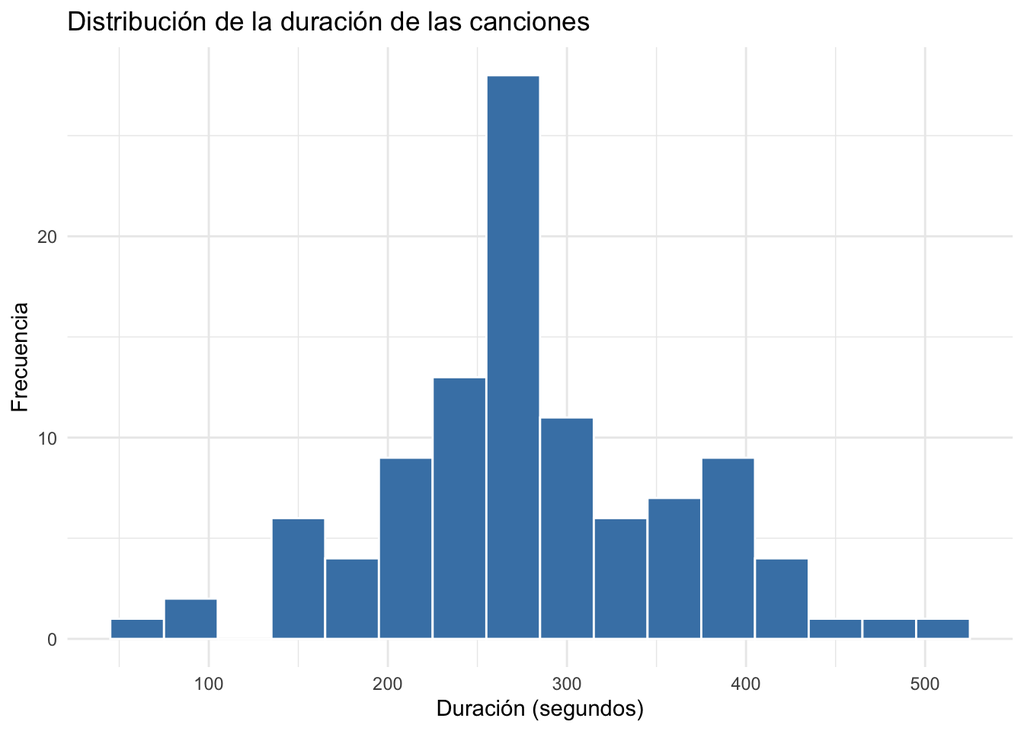

```r
ggplot(data, aes(x = track_duration_ms / 1000)) +
  geom_histogram(binwidth = 30, fill = "steelblue", color = "white") +
  labs(
    title = "Distribución de la duración de las canciones",
    x = "Duración (segundos)",
    y = "Frecuencia"
  ) +
  theme_minimal()
```

## 3.2 Relación entre energía y bailabilidad

Aquí se explora cómo se relacionan las métricas de energía y bailabilidad de las canciones. El gráfico de dispersión con una línea de regresión ayuda a visualizar si las canciones más energéticas tienden a ser también más bailables, lo cual puede ofrecer información interesante sobre el estilo de las canciones.

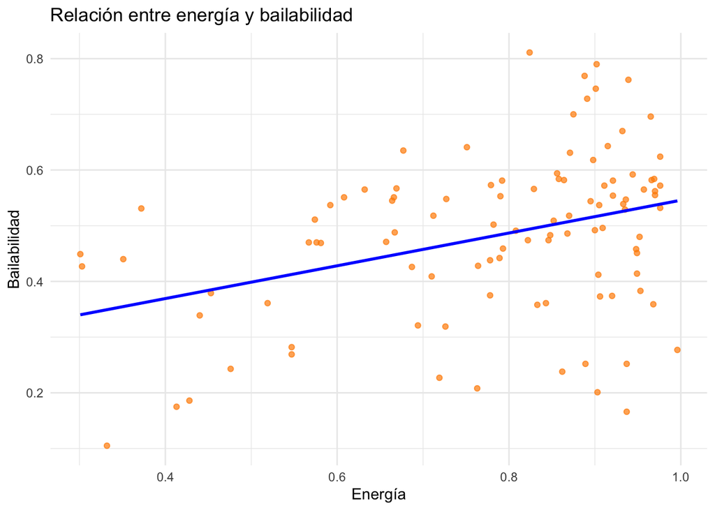

```r
ggplot(data, aes(x = track_energy, y = track_danceability)) +
  geom_point(alpha = 0.7, color = "darkorange") +
  geom_smooth(method = "lm", se = FALSE, color = "blue") +
  labs(
    title = "Relación entre energía y bailabilidad",
    x = "Energía",
    y = "Bailabilidad"
  ) +
  theme_minimal()
```

## 3.3 Estadísticas descriptivas de features numericos

Esta sección calcula estadísticas descriptivas para las características numéricas de las canciones (por ejemplo, duración, energía, etc.). Presentar los valores promedio, mínimo, máximo, etc., nos da una idea de cómo son los datos en términos de estos atributos.

```r
numerical_features <- songs_unique %>%
  select(where(is.numeric))

res <- pastecs::stat.desc(numerical_features) %>%
  as.matrix() %>%
  as.data.frame() %>%
  round(2)

res <- format(res, scientific = FALSE)

knitr::kable(data.frame(res), digits = 2)
```

|  | track_duration_ms | track_tempo | track_key | track_mode | track_danceability | track_energy | track_loudness | track_speechiness | track_acousticness | track_instrumentalness | track_liveness | track_valence | track_time_signature |
| --- | --- | --- | --- | --- | --- | --- | --- | --- | --- | --- | --- | --- | --- |
| nbr.val | 153.00 | 153.00 | 153.00 | 153.00 | 153.00 | 153.00 | 153.00 | 153.00 | 153.00 | 153.00 | 153.00 | 153.00 | 153.00 |
| nbr.null | 0.00 | 0.00 | 21.00 | 55.00 | 0.00 | 0.00 | 0.00 | 0.00 | 0.00 | 2.00 | 0.00 | 0.00 | 0.00 |
| nbr.na | 0.00 | 0.00 | 0.00 | 0.00 | 0.00 | 0.00 | 0.00 | 0.00 | 0.00 | 0.00 | 0.00 | 0.00 | 0.00 |
| min | 59733.00 | 73.62 | 0.00 | 0.00 | 0.10 | 0.24 | -17.30 | 0.02 | 0.00 | 0.00 | 0.04 | 0.04 | 1.00 |
| max | 522000.00 | 195.93 | 11.00 | 1.00 | 0.81 | 1.00 | -2.42 | 0.47 | 0.99 | 0.96 | 1.00 | 0.97 | 4.00 |
| range | 462267.00 | 122.31 | 11.00 | 1.00 | 0.71 | 0.76 | 14.88 | 0.44 | 0.99 | 0.96 | 0.96 | 0.93 | 3.00 |
| sum | 42186016.00 | 18108.41 | 787.00 | 98.00 | 76.14 | 120.62 | -1060.44 | 8.08 | 12.26 | 32.15 | 71.61 | 66.19 | 587.00 |
| median | 271400.00 | 117.31 | 4.00 | 1.00 | 0.51 | 0.85 | -6.46 | 0.04 | 0.01 | 0.06 | 0.38 | 0.44 | 4.00 |
| mean | 275725.59 | 118.36 | 5.14 | 0.64 | 0.50 | 0.79 | -6.93 | 0.05 | 0.08 | 0.21 | 0.47 | 0.43 | 3.84 |
| SE.mean | 6423.21 | 2.14 | 0.27 | 0.04 | 0.01 | 0.01 | 0.21 | 0.00 | 0.01 | 0.02 | 0.03 | 0.02 | 0.05 |
| CI.mean.0.95 | 12690.29 | 4.24 | 0.54 | 0.08 | 0.02 | 0.03 | 0.42 | 0.01 | 0.03 | 0.04 | 0.06 | 0.04 | 0.10 |
| var | 6312409625.65 | 703.22 | 11.28 | 0.23 | 0.02 | 0.03 | 7.03 | 0.00 | 0.03 | 0.07 | 0.12 | 0.06 | 0.37 |
| std.dev | 79450.67 | 26.52 | 3.36 | 0.48 | 0.15 | 0.18 | 2.65 | 0.04 | 0.17 | 0.27 | 0.35 | 0.25 | 0.61 |
| coef.var | 0.29 | 0.22 | 0.65 | 0.75 | 0.30 | 0.22 | -0.38 | 0.84 | 2.12 | 1.27 | 0.75 | 0.57 | 0.16 |

## 3.4 Grafico de correlación

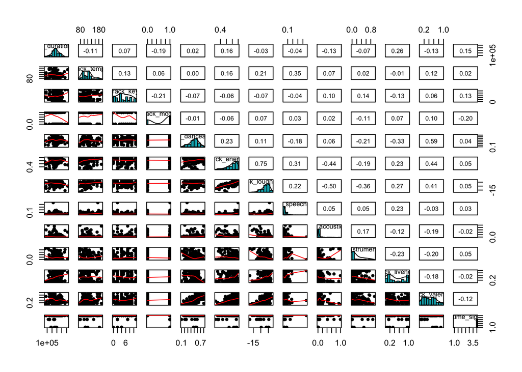

```r
pairs.panels(numerical_features,
  method = "pearson",
  hist.col = "#00AFBB",
  density = TRUE,
  ellipses = F
)
```

# 4 Análisis textual

## 4.1 Establecer una semilla para reproducibilidad

Aquí se establece una semilla para asegurar que el análisis de las palabras sea reproducible, lo que es importante para obtener los mismos resultados si se vuelve a ejecutar el análisis en el futuro.

```r
set.seed(123)
```

## 4.2 Frecuencia de palabras

En este bloque se crea una lista de las palabras más frecuentes en las letras de las canciones, después de eliminar las palabras vacías (stopwords) y algunas otras específicas de Soda Stereo. El gráfico resultante muestra cuáles son las palabras más recurrentes, lo que puede decirnos mucho sobre los temas recurrentes en las canciones.

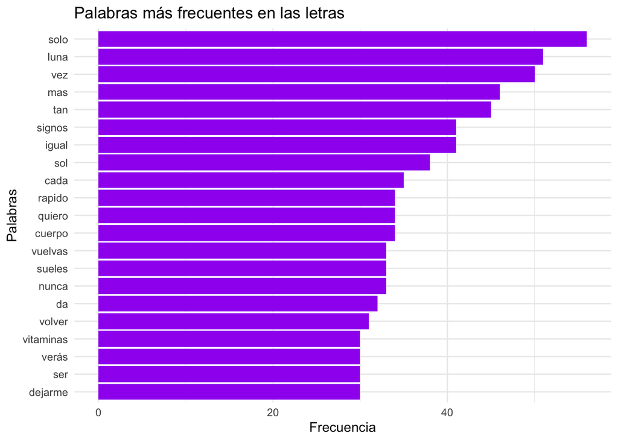

```r
stopwords_es <- stopwords("es")

# Crear un vector con las stopwords adicionales
# Sumo algo muy repetitivo en Soda (solo valido para Soda)
stopwords_adicionales <- c("ay", "oh")

stopwords_completas <- c(stopwords_es, stopwords_adicionales)

tokens <- data %>%
  unnest_tokens(word, lyrics) %>%
  anti_join(tibble(word = stopwords_completas), by = "word") %>%
  count(word, sort = TRUE)

tokens %>%
  top_n(20) %>%
  ggplot(aes(x = reorder(word, n), y = n)) +
  geom_col(fill = "purple") +
  coord_flip() +
  labs(
    title = "Palabras más frecuentes en las letras",
    x = "Palabras",
    y = "Frecuencia"
  ) +
  theme_minimal()
```

## 4.3 Nube de palabras

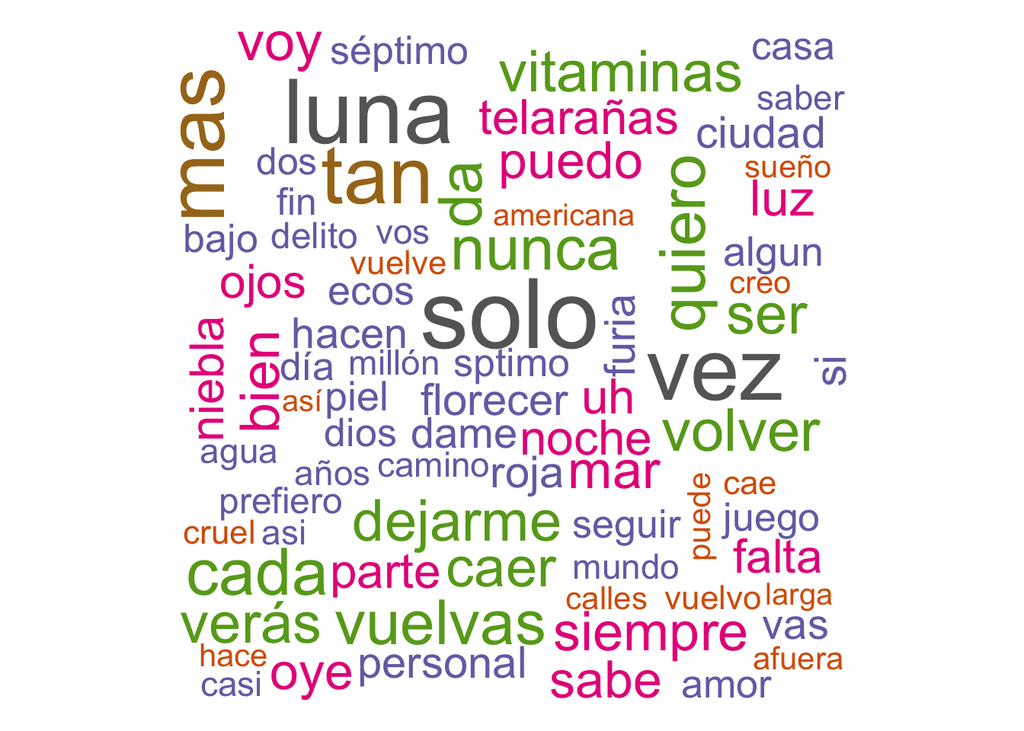

```r
wordcloud::wordcloud(
  words = tokens$word,
  freq = tokens$n,
  max.words = 100,
  colors = brewer.pal(8, "Dark2")
)
```

## 4.4 Análisis de sentimientos

Aquí se utiliza el léxico NRC para analizar los sentimientos presentes en las letras de las canciones. Los sentimientos son clasificados y contados, luego visualizados en un gráfico para mostrar cuál es el tono predominante (positivo, negativo, etc.) en las letras.

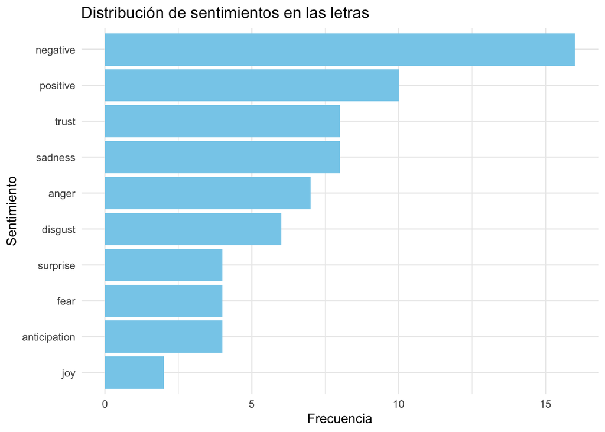

```r
# Análisis de sentimientos usando el léxico NRC
sentiments <- tokens %>%
  inner_join(get_sentiments("nrc"), by = "word") %>%
  count(sentiment, sort = TRUE)

ggplot(sentiments, aes(x = reorder(sentiment, n), y = n)) +
  geom_col(fill = "skyblue") +
  coord_flip() +
  labs(
    title = "Distribución de sentimientos en las letras",
    x = "Sentimiento",
    y = "Frecuencia"
  ) +
  theme_minimal()
```

## 4.5 Nube de palabras de sentimientos

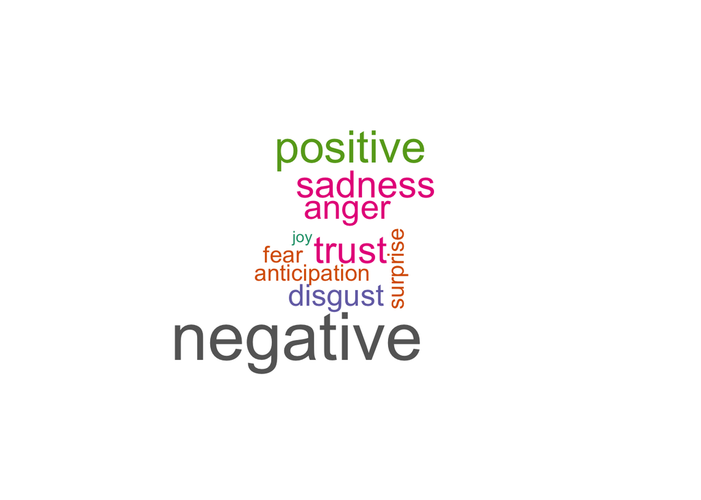

```r
wordcloud::wordcloud(
  words = sentiments$sentiment,
  freq = sentiments$n,
  min.freq = 1,
  colors = brewer.pal(8, "Dark2"),
)
```

# 5 Conclusión

Algo que llama la atención es cómo combinan temas tan humanos con su sonido característico, que puede ser suave y envolvente, pero también salvaje e intenso. No son canciones hechas solo para escuchar, sino para sentirlas. Tal vez por eso muchas de sus letras se quedan en la cabeza, porque realmente logran conectar con las emociones de quien las escucha.

En pocas palabras, Soda Stereo no solo hizo música, creó momentos y emociones que siguen vigentes. Hablar de ellos es hablar de poesía hecha canción, algo que muy pocas bandas logran.